# Aprendizaje supervisado

Luz Frias

2017-02-01

# Regresión lineal

- Solución muy simple, pero que en ocasiones funciona bastante bien
- Muy apropiada si la relación subyacente entre variables predictoras y objetivo es linear
- Métodos más complejos son una generalización de la regresión lineal
- Fácilmente interpretable (caja blanca)

# Regresión lineal

- Aproxima una recta utilizando mínimos cuadrados
- Ver 01_linear_regression

# Regresión lineal

- Pros:
  - Simple de calcular
  - Interpretable
- Cons:
  - Sensibles a outliers
  - Malos resultados si la relación no es lineal
  - Mucho sesgo (tiene a underfit)

# Árboles de decisión

- Dividen el espacio de las variables predictoras.
- La decisión a tomar sigue una estructura de árbol, por lo que es fácilmente interpretable
- Suele funcionar bastante bien
- Se pueden aplicar en problemas de regresión y clasificación

# Árboles de decisión - algoritmo

1. Se elige la variable más predictora (la que mejor separa)
2. Se sigue dividiendo hasta que la división es pura o no existen más variables.

# Árboles de decisión - divisiones

- Si una división deja a un lado observaciones de una clase y a otro los de otra, se considera pura
- La impureza usualmente se mide con la entropía. A menor entropía (mayor homogeneidad), mejor división

# Árboles de decisión - poda

- El algortimo de construcción de un árbol suele causar over-fitting
- Se soluciona podando las ramas del árbol. Para ello se saca del entrenamiento un conjunto de test, y se poda donde se minimiza el error en este conjunto

# Árboles de decisión

- Ver 02_decision_tree

# Árboles de decisión

- Pros:
  - Fáciles de interpretar
  - Computacionalmente poco costosos
  - Útil para extraer importancia de variables
- Cons
  - Inestabilidad: un pequeño cambio en el dataset, suele cambiar el árbol
  - Provocan overfitting o underfitting fácilmente
  - Grandes árboles complican la interpretación

# Redes neuronales

- Similares al comportamiento de las neuronas humanas
- Se consideran un aproximador universal a cualquier tipo de función

# Redes neuronales - referencias

- [Redes neuronales con TensorFlow playground](https://cloud.google.com/blog/big-data/2016/07/understanding-neural-networks-with-tensorflow-playground)
- [Guía visual e interactiva](https://jalammar.github.io/visual-interactive-guide-basics-neural-networks)
- [Efectividad de las RNN](http://karpathy.github.io/2015/05/21/rnn-effectiveness/)

# Redes neuronales

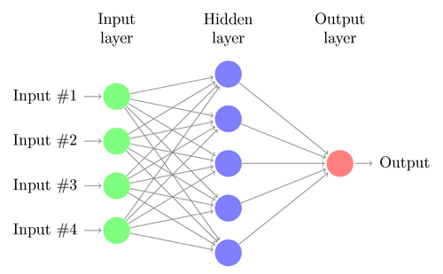

# Neuronas

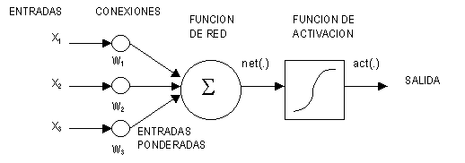

# Función de activación

- Transforma las entradas ponderadas en una salida
- Se diferencian especialmente en el rango de salida (-Inf, Inf), (-1, 1), …
- Para algunas funciones de activación, el rango de entrada es estrecho. En estos casos, es importante normalizar (centrar y escalar)

# Función de activación

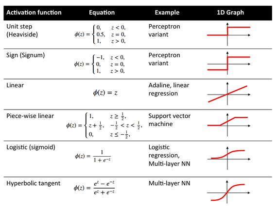

# Función de activación

Prueba en tensorflow playground a elegir diferentes funciones de activación para un mismo problema

# Topologías

- La forma en la que se conectan se denomina topología
- [Listado de topologías](http://www.asimovinstitute.org/neural-network-zoo/)
- Cada topología suele resolver un tipo de problema mejor que otro. Por ejemplo:
  - Convolucionales: reconocimiento de imágenes
  - Recurrentes: reconocimiento de voz
  - LSTM: composición de palabras y música

# Topologías

- Lo que determina una u otra es:
  - Número de capas
  - Conexiones entre nodos: ¿la salida viaja siempre hacia delante, o hay bucles, …?
  - Número de nodos por capa

# Topologías

- Los nodos de entrada reciben la señal sin procesar
- El número de nodos de salida viene determinado por el número de niveles de la clase, o número de salidas
- El # capas intermedias y la cantidad de neuronas viene determinada por la complejidad del problema, la cantidad de ruido, …
- Conviene empezar con redes simples y, si no funcionan, ir añadiendo capas y neuronas

# Topologías

Prueba en tensorflow playground a elegir diferentes topologías (# capas y # neuronas por capa) para un mismo problema

# Algoritmo de entrenamiento

- Lo más común: utilizar el algoritmo de backpropagation
- Fase 1: propagación. Cada propagación, implica:
  - Forward: se aplican los pesos actuales y la función de propagación para obtener el valor de salida
  - Backward: se calcula el error (real vs predicho) y se propaga hacia atrás
- Fase 2: actualización de pesos. Se modifican utilizando descenso de gradiente, aplicando una modificación relacionada con el learning rate. Learning rates altos aprendes más rápido, pero son más inestables.

# Algoritmo de entrenamiento

- [Visualización](http://vis.supstat.com/2013/03/gradient-descent-algorithm-with-r/)

# Algoritmo de entrenamiento

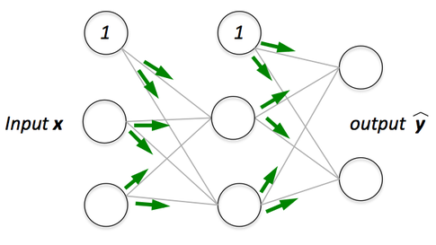

# Algoritmo de entrenamiento

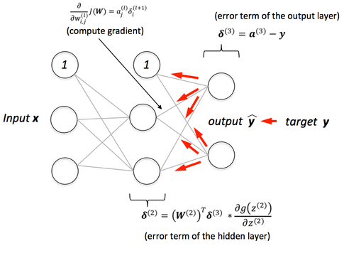

# Algoritmo de entrenamiento

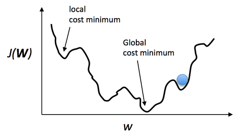

# Entrenamiento

Prueba en tensorflow playground a elegir diferentes learning rates para un mismo problema

# Deep Learning

- Redes de neuronas complejas (gran cantidad de capas intermedias)
- Estado del arte de la inteligencia artificial

# Deep Learning

- Frameworks
  - Tensorflow
  - Torch
  - mxnet
  - y más…

# Aplicaciones curiosas

- [Ostagram](https://ostagram.ru/static_pages/lenta?last_days=30&locale=en)
- [Auto-generación](http://karpathy.github.io/2015/05/21/rnn-effectiveness/) de textos de Shakespeare, artículos de wikipedia, código fuente
- [Composición musical](http://www.hexahedria.com/2015/08/03/composing-music-with-recurrent-neural-networks/)
- [Sunspring](https://www.youtube.com/watch?v=LY7x2Ihqjmc)

# Redes neuronales - Pros y cons

- Cons:
  - Muy caja negra
  - Coste computacional
  - Tienden hacia el under o overfitting
  - Suelen necesitar conjuntos grandes de entrenamiento
- Pros:
  - Precisos, se adaptan bien a problemas diferentes
  - Son superiores a otros modelos en ciertos problemas
  - Menor importancia del feature engineering

# Redes neuronales

- Ver 03_neural_nets.R

# Random forests

- Los árboles de decisión son potentes e interpretables, pero en general tienen poca precisión. Su estructura varía mucho dependiendo de los datos con los que se entrene
- Esto se puede solventar utilizando ensembles de árboles

# Ensembles de árboles

- Se utilizan meta-algoritmos:
- Bagging
- Boosting

# Bagging

- Boostrap aggregation
- Ensembles en paralelo
- Disminuye la varianza del modelo, evitando el overfitting

# Bagging

- Se cogen conjuntos de entrenamiento distintos (repitiendo datos, ya que no suele haber suficientes) y para cada uno de ellos se entrena un modelo
- El resultado es:
  - En problemas de clasificación, la clase con más “votos”
  - En problemas de regresión, la media

# Boosting

- Ensembles secuenciales
- Disminuye el sesgo del modelo, evitando el underfitting

# Boosting

- En lugar de crear un modelo complejo, crea muchos simples
- El modelo de una capa posterior intenta clasificar aquellas observaciones en las que no funciona bien el modelo anterior
- Es decir, se van modelando los residuos

# Random forests

- Es una implementación concreta del bagging de árboles de decisión
- Además, selecciona aleatoriamente las features para añadir diversidad
- La salida se decide mediante votación / promedio de la salida de los árboles

# Random forests - pros y cons

- Pros
  - Suelen funcionar bien en muchos casos de uso
  - Al escoger subconjuntos para entrenar, van bien al tener muchos datos
  - Preparados para reducir la varianza del modelo, robustos ante overfitting
- Cons
  - Caja negra, aunque “menos” que otros métodos, gracias a que se puede extraer la importancia de variables

# Random forests

Ver 04_random_forests